# Introductory Statistics with R - Chapter 2

Arthur Ryman

February 12, 2016

# CKME 132 Data Analytics: Basic Methods

### Introductory Statistics with R

### Chapter 2: The R environment

[figure not shown]

# Introduction

- this presentation is based on *Introductory Statistics with R*, *Chapter 2: The R environment*
- this is an R Markdown presentation
  - R Markdown let’s you combine R input and output, including graphs, with text
  - for more details on using R Markdown see http://rmarkdown.rstudio.com.

# 2 The R environment

- this chapter describes how to work with the R environment
- it describes
  - workspaces
  - graphical devices and their parameters
  - elementary programming
  - data entry

# 2.1 Session management

- your interaction with R occurs within the context of a **session**
- in RStudio there is
  - a session associated with the console
  - a temporary session created whenever you Knit an R markdown document

# 2.1.1 The workspace

- whenever you create a variable, it gets added to the workspace
- list all the variables in your workspace using the `ls()` function

```r
ls()
```

```
## character(0)
```

- the result of `ls()` is a character vector of variable names
- we haven’t created any variables in this session yet so the list is empty
- run all the commands we executed in Chapter 1

```r
library(knitr)
knit('iswr-ch01.Rmd')
```

- now list the variables again to see what was created

```r
ls()
```

```
##  [1] "bmi"           "d"             "exp.lean"      "exp.obese"
##  [5] "fpain"         "fseverity"     "height"        "hh"
##  [9] "intake.post"   "intake.pre"    "intake.sorted" "juul.7.14"
## [13] "l"             "m"             "mylist"        "o"
## [17] "pain"          "same"          "sel"           "severity"
## [21] "v"             "v1"            "v2"            "v3"
## [25] "weight"        "x"             "xbar"          "y"
```

- you can remove unneeded variables using `rm()`
- remove `height` and `weight`

```r
rm(height, weight)
```

- you can remove all variables from the workspace by giving `rm()` a list argument
  - you can also remove variables using RStudio menu commands

```r
rm(list=ls())
```

- by default, `ls()` omits variables that begin with a dot (.) since these are normally system variables
- you can really list ALL the variables (but don’t delete them!)

```r
ls(all=TRUE)
```

```
##  [1] ".Random.seed"  "bmi"           "d"             "exp.lean"
##  [5] "exp.obese"     "fpain"         "fseverity"     "hh"
##  [9] "intake.post"   "intake.pre"    "intake.sorted" "juul.7.14"
## [13] "l"             "m"             "mylist"        "o"
## [17] "pain"          "same"          "sel"           "severity"
## [21] "v"             "v1"            "v2"            "v3"
## [25] "x"             "xbar"          "y"
```

- you can save the state of your workspace and restore it later

```r
save.image()
```

- by default the image is saved to a file named `.Rdata` - you can also provide a file name
- the R environment prompts you to save the image when you quit
- the workspace image file `.Rdata` is loaded by default when you start a new session
- you can save and load individual R objects using `save()` and `load()`

```r
bmi
```

```
## [1] 19.59184 22.22222 20.93664 24.93075 31.37799 19.73630
```

```r
save(bmi, file='bmi.Rdata')
bmi <- 1:3
bmi
```

```
## [1] 1 2 3
```

```r
load('bmi.Rdata')
bmi
```

```
## [1] 19.59184 22.22222 20.93664 24.93075 31.37799 19.73630
```

# 2.1.2 Textual Output

- the workspace does not contain the output you generate
- you can copy and paste output from the console
- you can divert output to a file using `sink()`
  - of course, it is better to use R markdown!

```r
sink('myfile')
ls()
sink()
```

- R looks in the working directory if you don’t specify the file path
- get the working directory using `getwd()`

```r
getwd()
```

```
## [1] "/Users/arthurryman/Documents/repositories/RyersonU-DataScienceLab/ckme132-w2016-5j0-students"
```

- set the working directory using `setwd()`

```r
(work.dir <- getwd())
```

```
## [1] "/Users/arthurryman/Documents/repositories/RyersonU-DataScienceLab/ckme132-w2016-5j0-students"
```

```r
setwd('/Users')
getwd()
```

```
## [1] "/Users"
```

```r
setwd(work.dir)
getwd()
```

```
## [1] "/Users/arthurryman/Documents/repositories/RyersonU-DataScienceLab/ckme132-w2016-5j0-students"
```

- the initial working directory depends on how you start R
- you can configure RStudio to start in a specific working directory

# 2.1.3 Scripting

- the console is great for interactive exploration
- when you are finished exploring you will want to store your R code in a file so you can repeat them easily
- you can store R code in a plain `.R` script file or a `.Rmd` markdown file
  - you can run a script file using `source()`
  - you can run a markdown file using `knit()`
- you can develop R code files interactively using a script editor
  - the script editor lets you run individual lines of code
- for example, consider the script `norm-hist.R`
  - opens a PDF graphics device
  - plots a histogram of the normal distribution
  - closed the graphics device

```r
cat(readLines("norm-hist.R"), sep="\n" )
```

```
## pdf("norm-hist.pdf")  # set graphical output file
## hist(rnorm(100))      # generate 100 N(0,1) variates and plot their histogram
## dev.off()             # close the graphical output file
```

- run the script using `source()`, echoing the lines

```r
source('norm-hist.R', echo = TRUE)
```

```
##
## > pdf("norm-hist.pdf")
##
## > hist(rnorm(100))
```

```
##
## > dev.off()
## quartz_off_screen
##                 2
```

- R maintains a history of all the commands you enter
- display the most recent commands using `history()`
- save and load the history using `savehistory()` and `loadhistory()`

# 2.1.4 Getting help

- R has many more commands than you can possibly memorize
- R has an extensive built-in help system
- use the RStudio menus or enter help commands in the console
- launch the help browser using `help.start()`

```r
help.start()
```

- look up help for a specific function, e.g. `plot`

```r
help("plot")
```

- or use the shortcut

```r
?plot
```

- get a list of commands that refer to a topic

```r
apropos("mean")
```

```
##  [1] ".colMeans"     ".rowMeans"     "colMeans"      "kmeans"
##  [5] "mean"          "mean.Date"     "mean.default"  "mean.difftime"
##  [9] "mean.POSIXct"  "mean.POSIXlt"  "rowMeans"      "weighted.mean"
```

- display a help page of commands that refer to a topic

```r
help.search("mean")
```

- read “An Introduction to R” which comes with the R distribution:
  - https://cran.r-project.org/doc/manuals/r-release/R-intro.pdf

# 2.1.5 Packages

- an R installation contains one or more **libraries** of **packages**
- some packages are part of the basic installation
- other packages can be downloaded from CRAN (more than 6,000)
- you can create your own packages
- a **library** is a folder on your disk
- a **system library** is a library that is created when R is installed
- you may not have file permission to modify the system libraries
- you may be able to create private user libraries (see `help(".Library"))`
- a package contains specialized function
  - not needed by everyone
- a package may contain:
  - R code
  - data sets
  - dynamically loadable native code (usually C or Fortran)
- you load a package using `library()`

```r
library(survival)
```

- loaded packages are not part of the workspace
- you must reload any needed packages when you start a new session
- you can remove a loaded package using `detach()`

```r
detach("package:survival")
```

# 2.1.6 Built-in data

- many packages contain large data sets
- to avoid excess memory consumption, many packages implement **lazy loading**
- with lazy loading, the data set appears to be available but is not actually loaded into memory until the data is referenced for the first time
  - e.g. `thuesen` in the `ISwR` package is available but not actually loaded
- some packages require that you explicitly load data using `data()`

```r
data("thuesen")
```

- `data()` searches the data directories of the loaded packages for a file with the specified base name
  - subdirectories named `data` are also searched
- if a match is found then actions are performed depending on the file extension
  - `.tab` files are read using `read.table()`
  - `.R` files are executed using `source()`

# 2.1.7 `attach` and `detach`

- R maintains a **search path** of scopes for looking up variables

```r
search()
```

```
##  [1] ".GlobalEnv"        "package:ISwR"      "package:knitr"
##  [4] "package:stats"     "package:graphics"  "package:grDevices"
##  [7] "package:utils"     "package:datasets"  "package:methods"
## [10] "Autoloads"         "package:base"
```

- `.GlobalEnv` (at position 1) is the set of variable defined in the workspace
- when you reference a variable, R checks each scope in the search path for the variable and returns the first one it finds
  - a variable in earlier scopes on the search path will **mask** variables with the same name in later scopes
  - if R is searching for a variable of a specific type, e.g. a function, then it will skip variable of the same name that are of a different type
- you can abbreviate access to the components of a data frame by adding it to the search path using `attach()`

```r
attach(thuesen)
search()
```

```
##  [1] ".GlobalEnv"        "thuesen"           "package:ISwR"
##  [4] "package:knitr"     "package:stats"     "package:graphics"
##  [7] "package:grDevices" "package:utils"     "package:datasets"
## [10] "package:methods"   "Autoloads"         "package:base"
```

- R adds the data frame immediately after `.GlobalEnv`, i.e. at position 2
- with `thuesen` on the search path, instead of writing `thuesen$blood.glucose`, write just `blood.glucose`

```r
blood.glucose
```

```
##  [1] 15.3 10.8  8.1 19.5  7.2  5.3  9.3 11.1  7.5 12.2  6.7  5.2 19.0 15.1
## [15]  6.7  8.6  4.2 10.3 12.5 16.1 13.3  4.9  8.8  9.5
```

- attached data frames always come after the workspace on the search path
- you can make R search a given data frame before the workspace by using `with()`

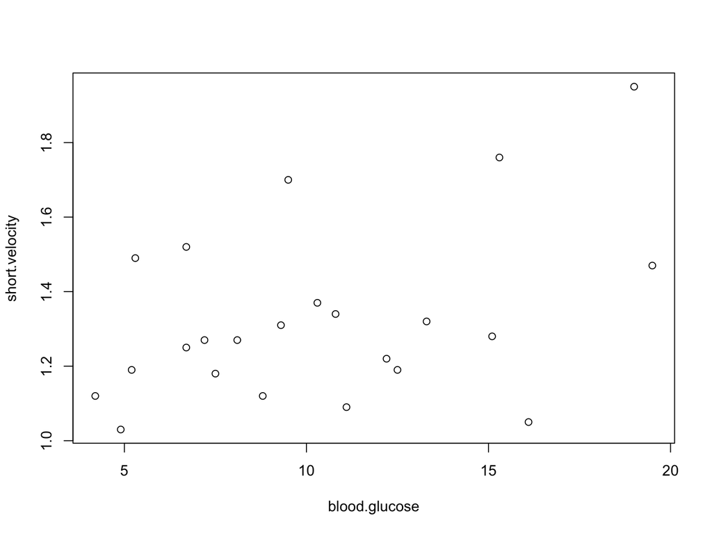

```r
with(thuesen, plot(blood.glucose, short.velocity))
```

- remove a data frame from the search path using `detach()`

```r
detach()
search()
```

```
##  [1] ".GlobalEnv"        "package:ISwR"      "package:knitr"
##  [4] "package:stats"     "package:graphics"  "package:grDevices"
##  [7] "package:utils"     "package:datasets"  "package:methods"
## [10] "Autoloads"         "package:base"
```

- by default, the data frame in position 2 is removed
  - you can give `detach()` an argument to remove a specific data frame

# 2.1.8 `subset`, `transform`, and `within`

- R provides some additional functions to make referencing components of a data frame easier
- use `subset()` to select a subset of the rows of a data frame based on a condition

```r
thue2 <- subset(thuesen, blood.glucose < 7)
thue2
```

```
##    blood.glucose short.velocity
## 6            5.3           1.49
## 11           6.7           1.25
## 12           5.2           1.19
## 15           6.7           1.52
## 17           4.2           1.12
## 22           4.9           1.03
```

- you can also use `subset()` on a vector
- this is the same as indexing the vector except that `NA` entries are excluded

```r
v1 <- c(1,2,3,NA,5,6,7)
subset(v1, v1 < 6)
```

```
## [1] 1 2 3 5
```

- `select()` has an argument `select` which let’s you select which variables from the data frame to select

```r
subset(thuesen, blood.glucose < 7, select = short.velocity)
```

```
##    short.velocity
## 6            1.49
## 11           1.25
## 12           1.19
## 15           1.52
## 17           1.12
## 22           1.03
```

- use `transform()` to create new components of a data frame

```r
thue3 <- transform(thuesen, log.gluc=log(blood.glucose))
head(thue3)
```

```
##   blood.glucose short.velocity log.gluc
## 1          15.3           1.76 2.727853
## 2          10.8           1.34 2.379546
## 3           8.1           1.27 2.091864
## 4          19.5           1.47 2.970414
## 5           7.2           1.27 1.974081
## 6           5.3           1.49 1.667707
```

- `transform()` does not allow **chained** calculations
  - the new variables can only depend on the existing variables
- use `within()` for more complex transformations

```r
thue4 <- within(thuesen, {
  log.gluc <- log(blood.glucose)
  m <- mean(log.gluc)
  centered.log.gluc <- log.gluc - m
  rm(m)
})
head(thue4)
```

```
##   blood.glucose short.velocity centered.log.gluc log.gluc
## 1          15.3           1.76         0.4818798 2.727853
## 2          10.8           1.34         0.1335731 2.379546
## 3           8.1           1.27        -0.1541090 2.091864
## 4          19.5           1.47         0.7244414 2.970414
## 5           7.2           1.27        -0.2718920 1.974081
## 6           5.3           1.49        -0.5782662 1.667707
```

- `within()` collects all the variables defined in the **compound statement** and returns them in a data frame
  - note how the intermediate variable `m` was removed using `rm()`

# 2.2 The graphics subsystem

- R lets you generate simple plots
- you can superimpose a curve on it
- you can modify the default behaviour
  - add annotations
  - change the axes
  - use labels instead of numbers
  - use irregularly placed tick marks
- there other graphics packages, which are not covered in ISwR
  - `grid`
  - `lattice`
  - `ggplot2`

# 2.2.1 Plot layout

- the R graphics model defines a figure region (for a single plot)
  - central plotting region
  - margins
- coordinates in the plotting region are specified in **data units**
- coordinates in the margins are specified in
  - **lines of text** perpendicular to the axis
  - **data units** along the axis
- a standard **x-y plot** has
  - an x-axis title
  - a y-axis title
  - a main title above the plot
  - a subtitle below the plot

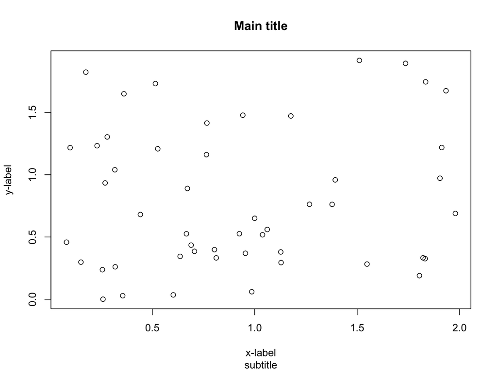

```r
x <- runif(50, 0, 2)
y <- runif(50, 0, 2)
plot(x, y, main="Main title", sub="subtitle", xlab="x-label", ylab="y-label")
```

- you can place additional points and lines in the plot either when the plot is created or after using `points()` and `lines()`
- you can place text in the plot using `text()`
  - use `abline()` to draw vertical and horizontal lines in this example

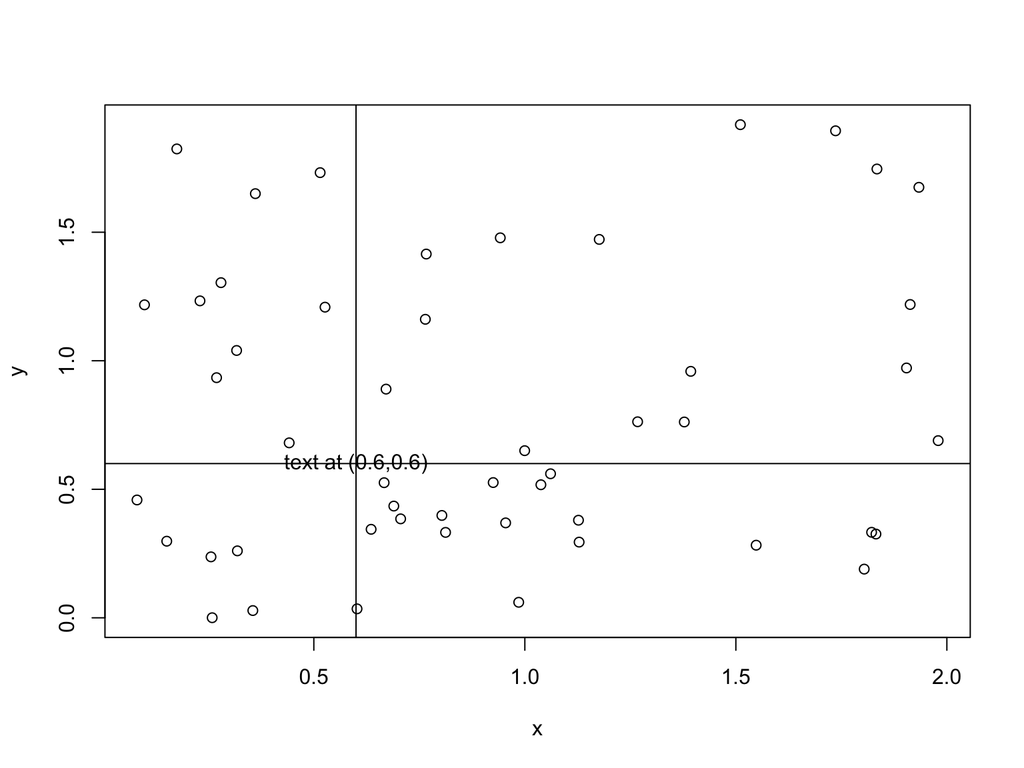

```r
plot(x,y)
text(0.6,0.6, "text at (0.6,0.6)")
abline(h=0.6,v=0.6)
```

- use `mtext()` to place text in the margins
- use line coordinates

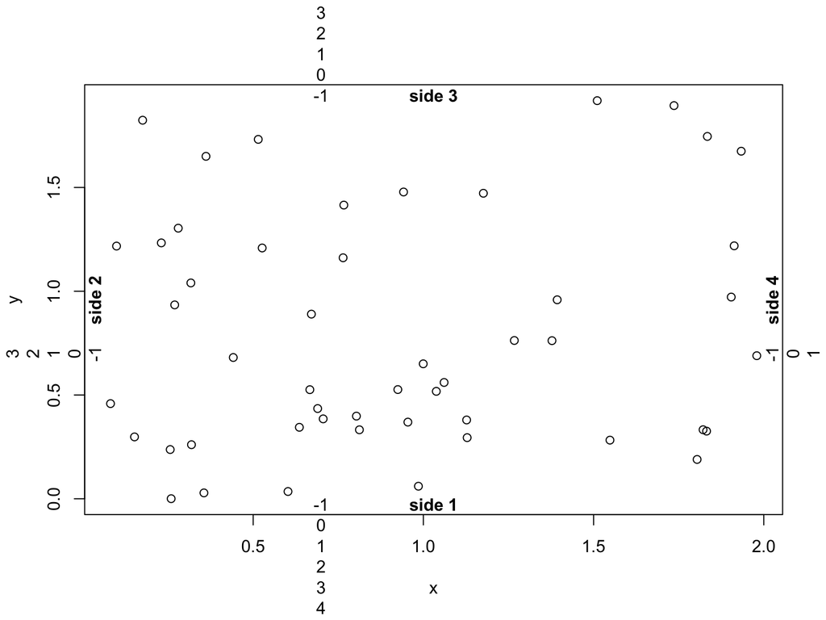

```r
plot(x,y)
for(side in 1:4) mtext(-1:4, side=side, at=.7, line=-1:4)
mtext(paste("side", 1:4), side=1:4, line=-1, font=2)
```

# 2.2.2 Build a plot from pieces

- high-level plots are composed of elements, each of which can be drawn separately with finer control
- to achieve ultimate control, draw the plot without the element, then add it
- the following code draws nothing but sets the coordinate system of the plot
  - `type="n"` suppresses drawing the points
  - `axes=F` suppresses drawing the axes and the box surrounding the plot

```r
plot(x,y, type="n", xlab="", ylab="", axes=F)
```

- now add the elements

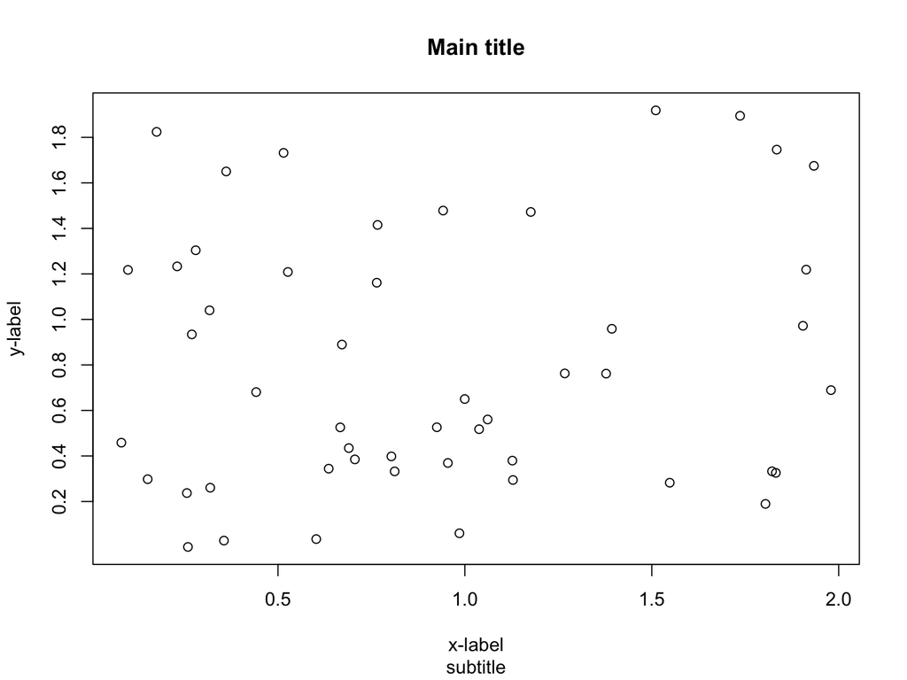

```r
plot(x,y, type="n", xlab="", ylab="", axes=F)
points(x,y)
axis(1)
axis(2, at=seq(0.2,1.8,0.2))
box()
title(main="Main title", sub="subtitle", xlab="x-label", ylab="y-label")
```

- plotting points with `type="n"` is also useful for establishing the overall coordinate system of the plot when you want to plot several groups of data
- plot the entire set of points with `type="n"`
- then plot each group using `points()` in a different colour
- alternatively, plot all points at once using a vector argument for `col`

# 2.2.3 Using `par`

- use `par()` to set graphics parameters for multiple plots
- some parameters can only be set using `par()
- you can set the following
  - line width and type
  - character size and font
  - colour
  - style of axis calculation
  - size of the plot and figure regions
  - clipping
  - etc.
- you can divide a figure into subfigures using `mfrow` and `mfcol`
- e.g. reduce the margin sizes from the default of `c(5,4,4,2)`

```r
par(mar=c(4,4,2,2)+0.1)
```

# 2.2.4 Combining plots

- combining plots requires some considerations in order to produce a good result
- the following code is not good enough

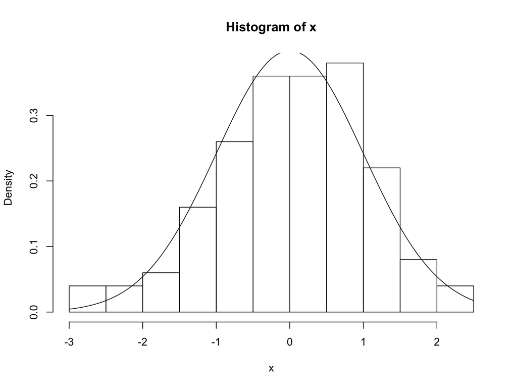

```r
set.seed(42)
x <- rnorm(100)
hist(x,freq=F)
curve(dnorm(x),add=T)
```

- the problem is that the peak of the curve may get clipped because its height was not taken into account in the histogram
- the solution is to compute the actual limit of the y-axis

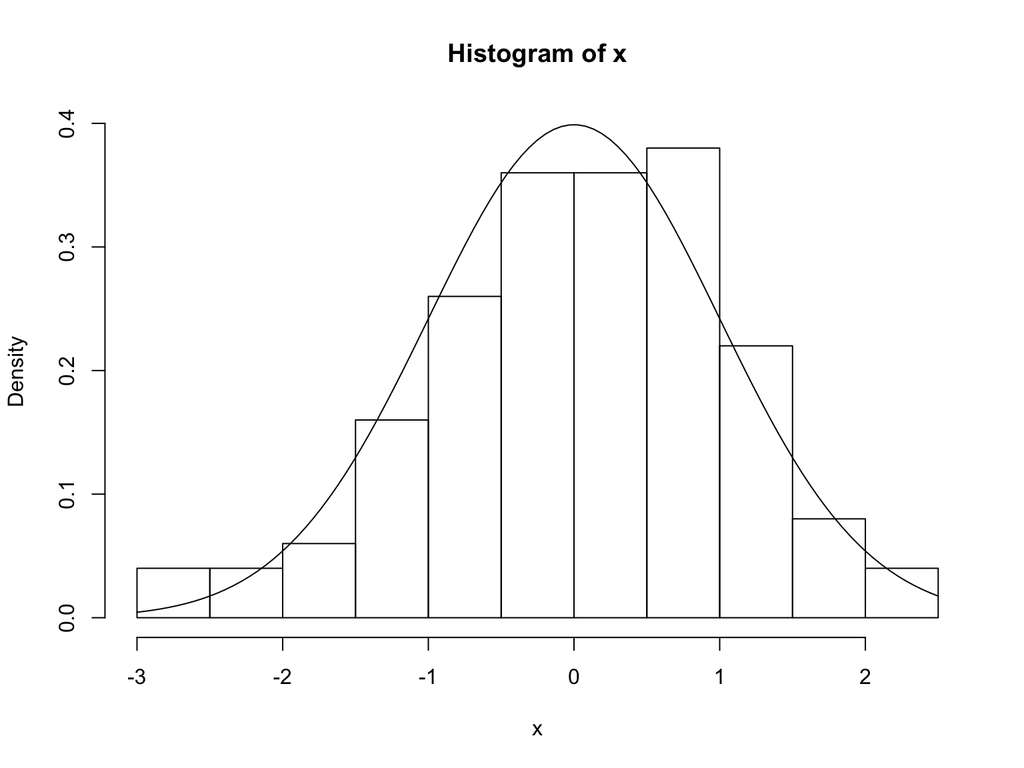

```r
h <- hist(x, plot=F)
ylim <- range(0, h$density, dnorm(0))
hist(x, freq=F, ylim=ylim)
curve(dnorm(x), add=T)
```

# 2.3 R programming

- the main focus of this book is using the available packages to do statistics
- however, you can also write your own functions in R
- this allows you to easily reuse code
- as an illustration of the power of R programming, let’s wrap the preceding plotting code in a function

```r
hist.with.normal <- function(x, xlab=deparse(substitute(x)), ...)
{
  h <- hist(x, plot=F, ...)
  s <- sd(x)
  m <- mean(x)
  ylim <- range(0, h$density, dnorm(0, sd=s))
  hist(x, freq=F, ylim=ylim, xlab=xlab, ...)
  curve(dnorm(x,m,s), add=T)
}
```

- the default value for `xlab` is set to the expression used for `x`
- the `...` argument indicates other arguments which can then be passed to the other plot function calls
- now let’s call this function

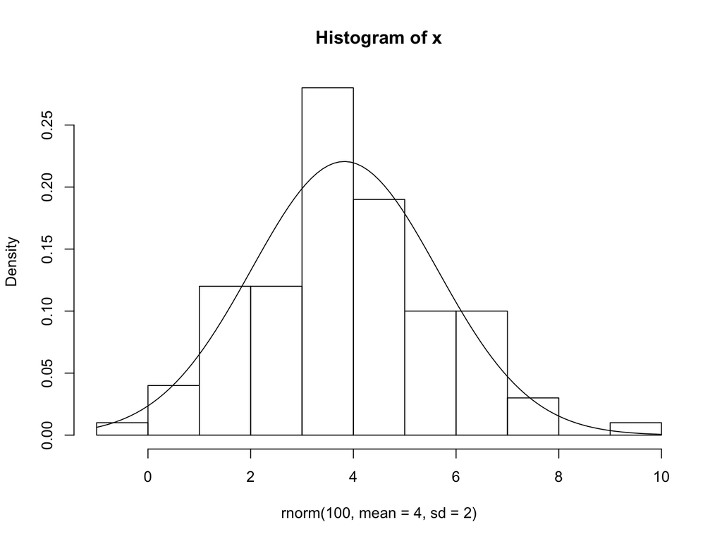

```r
hist.with.normal(rnorm(100, mean=4, sd=2))
```

- you can learn more about R programming by looking at the definition of other people’s functions
- print the definition of a function the same as you print the value of any other variable

```r
hist.with.normal
```

```
## function(x, xlab=deparse(substitute(x)), ...)
## {
##   h <- hist(x, plot=F, ...)
##   s <- sd(x)
##   m <- mean(x)
##   ylim <- range(0, h$density, dnorm(0, sd=s))
##   hist(x, freq=F, ylim=ylim, xlab=xlab, ...)
##   curve(dnorm(x,m,s), add=T)
## }
```

# 2.3.1 Flow control

- R is a true programming language
  - conditional exectution
  - looping
- the following code computes $x = \sqrt{y}$ using Newton’s method

```r
y <- 12345
x <- y/2
while (abs(x*x - y) > 1e-10) x <- (x + y/x)/2
x
```

```
## [1] 111.1081
```

```r
x^2
```

```
## [1] 12345
```

```r
abs(x^2-y)
```

```
## [1] 5.456968e-12
```

- a `while` loop executes a statement while a logical condition is `TRUE`
- a `repeat` loop excutes a statement until you `break` out of it

```r
x <- y/2
repeat {
  x <- (x + y/x)/2
  if (abs(x*x - y) < 1e-10) break
}
x
```

```
## [1] 111.1081
```

- here the `repeat` loop executes a **compound** statement which consists of several other statements enclosed by `{ }`
- the `if` statement performs **conditional execution**
- the `break` statement exits the enclosing loop
- the break condition can be modified using `all()` to allow computation of a vector of results
- this is less efficient since the loop only breaks when all results have converged so some results would be computed to a higher accuracy than required

```r
(y <- 1:10)
```

```
##  [1]  1  2  3  4  5  6  7  8  9 10
```

```r
x <- y/2
repeat {
  x <- (x + y/x)/2
  if (all(abs(x*x - y) < 1e-10)) break
}
x
```

```
##  [1] 1.000000 1.414214 1.732051 2.000000 2.236068 2.449490 2.645751
##  [8] 2.828427 3.000000 3.162278
```

```r
x^2
```

```
##  [1]  1  2  3  4  5  6  7  8  9 10
```

```r
abs(x^2 - y)
```

```
##  [1] 2.220446e-15 4.440892e-16 4.440892e-16 0.000000e+00 8.881784e-16
##  [6] 8.881784e-16 8.881784e-16 1.776357e-15 0.000000e+00 1.776357e-15
```

- the `for` loop executes a statement for each value in a given set

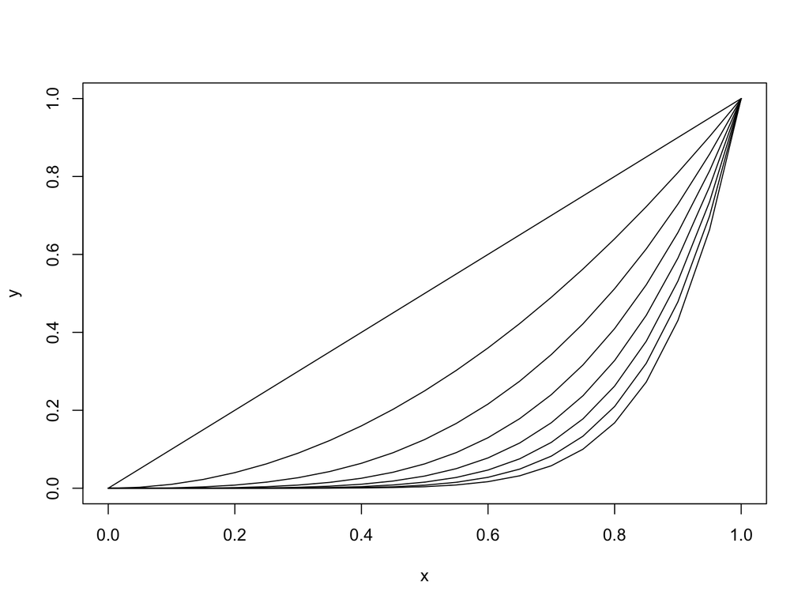

```r
x <- seq(0,1,.05)
plot(x, x, ylab="y", type="l")
for (j in 2:8) lines(x, x^j)
```

- the `for` loop is executed with `j=2`, `j=3`, …, `j=8`

# 2.3.2 Classes and generic functions

- in an **object-oriented** programming language each data object has a **class**
- a class defines the **methods** that act on the objects of the class
- different classes may contain methods of the same name, e.g. `print`
- R has some object-oriented features
- you can determine the class of an object using `class`

```r
class(TRUE)
```

```
## [1] "logical"
```

```r
class(42)
```

```
## [1] "numeric"
```

```r
class("Ryerson")
```

```
## [1] "character"
```

- you can write a **generic function** by calling `UseMethod`

```r
print
```

```
## function (x, ...)
## UseMethod("print")
## <bytecode: 0x7fd50b05bf88>
## <environment: namespace:base>
```

- `UseMethod` calls the `print` method for the class of the object being printed
- you can list all the `print` methods using `methods()`

```r
head(methods(print))
```

```
## [1] "print.aareg"   "print.acf"     "print.AES"     "print.anova"
## [5] "print.aov"     "print.aovlist"
```

- for example, `t.test()` returns an object of class `htest` (hypothesis test)

```r
(x <- t.test(bmi, mu=22.5))
```

```
##
##  One Sample t-test
##
## data:  bmi
## t = 0.34488, df = 5, p-value = 0.7442
## alternative hypothesis: true mean is not equal to 22.5
## 95 percent confidence interval:
##  18.41734 27.84791
## sample estimates:
## mean of x
##  23.13262
```

```r
class(x)
```

```
## [1] "htest"
```

```r
x$p.value
```

```
## [1] 0.7442183
```

- when an object of class `htest` is printed, the `print.htest()` method is called
- if there is no `print` method for a class then `print.default` is called

# 2.4 Data entry

- this book uses example data sets provided by the `ISwR` package
- to analyse your own data you have to read it into R somehow
- you can read data from files, databases, the web
- you can also enter data manually
  - using `c()` is only practical for manually entering small data sets
  - R provides a data editor for manually entering larger data sets

# 2.4.1 Reading from a text file

- the most convenient function for reading data files into R is `read.table()`
- this function produces a new data frame
- the function requires that the data set is stored in a plain, flat, ASCII text file
  - create this type of file with a text editor like Notepad on Windows or TextEdit on Mac OS X
- the first line of the file should contain a header that names the variables being measured
- the items in each line are separated by blanks, tabs, or other delimiters
- after the header (if present), each line of the file contains one row of data
  - each data row contains the measurements for one experimental unit
  - use the special value `NA` for missing data
- the `ISwR` package includes some data files in its `rawdata` subdirectory
- you can find the location of this subdirectory on your machine using `system.file()`
- the data for `thuesen` is stored in the file `thuesen.txt`

```r
thuesen.txt <- system.file("rawdata/thuesen.txt", package = "ISwR")
cat(readLines(thuesen.txt), sep="\n" )
```

```
## blood.glucose    short.velocity
## 15.3     1.76
## 10.8     1.34
## 8.1      1.27
## 19.5     1.47
## 7.2      1.27
## 5.3      1.49
## 9.3      1.31
## 11.1     1.09
## 7.5      1.18
## 12.2     1.22
## 6.7      1.25
## 5.2      1.19
## 19.0     1.95
## 15.1     1.28
## 6.7      1.52
## 8.6      NA
## 4.2      1.12
## 10.3     1.37
## 12.5     1.19
## 16.1     1.05
## 13.3     1.32
## 4.9      1.03
## 8.8      1.12
## 9.5      1.70
```

- read this file into a new data frame
  - use the argument `header=T` because the file has a header line

```r
thuesen2 <- read.table(thuesen.txt, header = T)
thuesen2
```

```
##    blood.glucose short.velocity
## 1           15.3           1.76
## 2           10.8           1.34
## 3            8.1           1.27
## 4           19.5           1.47
## 5            7.2           1.27
## 6            5.3           1.49
## 7            9.3           1.31
## 8           11.1           1.09
## 9            7.5           1.18
## 10          12.2           1.22
## 11           6.7           1.25
## 12           5.2           1.19
## 13          19.0           1.95
## 14          15.1           1.28
## 15           6.7           1.52
## 16           8.6             NA
## 17           4.2           1.12
## 18          10.3           1.37
## 19          12.5           1.19
## 20          16.1           1.05
## 21          13.3           1.32
## 22           4.9           1.03
## 23           8.8           1.12
## 24           9.5           1.70
```

- `read.table` assumes that any column that contains character data is a factor
- for example, consider the file `secretin.txt` which corresponds to the `ISwR` data frame named `secretin`

```r
secretin.txt <- system.file("rawdata/secretin.txt", package = "ISwR")
cat(readLines(secretin.txt), sep="\n" )
```

```
##    gluc person time repl time20plus time.comb
## 1    92      A  pre    a        pre       pre
## 2    93      A  pre    b        pre       pre
## 3    84      A   20    a        20+        20
## 4    88      A   20    b        20+        20
## 5    88      A   30    a        20+       30+
## 6    90      A   30    b        20+       30+
## 7    86      A   60    a        20+       30+
## 8    89      A   60    b        20+       30+
## 9    87      A   90    a        20+       30+
## 10   90      A   90    b        20+       30+
## 11   85      B  pre    a        pre       pre
## 12   85      B  pre    b        pre       pre
## 13   74      B   20    a        20+        20
## 14   76      B   20    b        20+        20
```

[output cut: 36 more lines]

- note that row numbers are included
- read the file:

```r
secretin2 <- read.table(secretin.txt)
summary(secretin2)
```

```
##       gluc      person  time    repl   time20plus time.comb
##  Min.   :74.0   A:10   20 :10   a:25   20+:40     20 :10
##  1st Qu.:84.0   B:10   30 :10   b:25   pre:10     30+:30
##  Median :87.5   C:10   60 :10                     pre:10
##  Mean   :86.7   D:10   90 :10
##  3rd Qu.:91.0   E:10   pre:10
##  Max.   :97.0
```

- note that R detects that the first row is one item shorter than the rest which have row numbers, and intreprets it as a header
- the first variable is numeric, the rest are factors
- `read.table` orders the factor levels alphabetically, which may not be what you want
- you may therefore need to reorder the factor levels after you read the file

```r
levels(secretin2$time)
```

```
## [1] "20"  "30"  "60"  "90"  "pre"
```

# 2.4.2 Further details on `read.table`

- `read.table` is very flexible and has many options
- consult the help system for full details
- here are some of the important options

### File format details

- specify the *field separator* using `sep=`
- specify the *NA strings* using `na.strings=`
- specify *quote* and *comment* delimiters using `quote=` and `comment.char`
- specify the handling of *unequal field count* using `fill=` and `flush=`

### Delimited file types

- the a a few variants of `read.table` that set the options to common values
  - these assume the first row is a header
- `read.csv` reads Comma-Separated Values (CSV)
- `read.csv2` is like `read.csv` except that comma is used as the decimal oint and semicolon is used as the field delimiter
  - useful for data from European countries
- `read.delim` is like `read.csv` except that TAB is the field delimiter
- `read.delim2` is like `read.csv2` except that TAB is the field delimiter

| Function | Decimal Point | Field Delimiter |
| --- | --- | --- |
| `read.csv` | PERIOD (.) | COMMA (,) |
| `read.csv2` | COMMA (,) | SEMICOLON (;) |
| `read.delim` | PERIOD (.) | TAB |
| `read.delim2` | COMMA (,) | TAB |

### Conversion of input

- control conversion of strings to factors using `stringsAsFactors=` and `as.is`
- specify datatype of columns using `colClasses`
  - improves efficiency
  - skip unwanted columns using `NULL`

# 2.4.3 The data editor

- R has a spreadsheet-like user interface for editing data frames
- edit the `airquality` data frame:

```r
aq <- edit(airquality)
```

- this assigns the edited data frame to a new data frame
- you can edit a data frame in place using `fix()`
- note that on Mac OS X you may see a error message like: “Error in check_for_XQuartz() : X11 library is missing: install XQuartz from xquartz.macosforge.org”
  - download and install the X11 library from http://www.xquartz.org

### Recommendation

- the data editor user interface is primitive compared to Excel
- use Excel instead and save worksheet in CSV format

# 2.4.4. Interfacing to other programs

- you may need to move data between R and other programs
- the simplest way to accomplish this is to export and import delimited text files in the other programs
- you can also use the `foreign` package
- it supports SPSS, SAS, Epi-Info, Stata, Systat, Minitab, and S-PLUS
- on Unix/Linux systems open Excel files using OpenOffice and export as CSV
- you can also use the Windows system clipboard
- select tabular data in Excel, then copy to clipboard
- then read the special “clipboard” file in R:

```r
read.table("clipboard", header=T)
```

- you can read data from databases
- use the `RODBC` package to read ODBC database connection
- refer to “R Data Import/Export” https://cran.r-project.org/doc/manuals/r-release/R-data.html

### Recommendation

- text files are the simplest way to read data into R
- export other formats to CSV
- write database query results as CSV

# 2.5 Exercises

2.1 Describe how to insert a value between two elements of a vector at a given position by using the append function (use the help system to find out). Without append, how would you do it?

- for example, consider this vector of some names:

```r
some.names <- c("Alberta", "British Columbia", "Ontario", "Quebec")
```

- insert more names between “British Columbia” and “Ontario” (after position 2):

```r
more.names <- c("Manitoba", "New Brunswick")
```

- Solution 1: Use `append()`

```r
append(some.names, more.names, after=2)
```

```
## [1] "Alberta"          "British Columbia" "Manitoba"
## [4] "New Brunswick"    "Ontario"          "Quebec"
```

- Solution 2: Without `append()`

```r
c(some.names[1:2], more.names, some.names[3:4])
```

```
## [1] "Alberta"          "British Columbia" "Manitoba"
## [4] "New Brunswick"    "Ontario"          "Quebec"
```

2.2 Write the built-in data set thuesen to a Tab-separated text file with write.table. View it with a text editor (depending on your system). Change the NA value to . (period), and read the changed file back into R with a suitable command. Also try importing the data into other applications of your choice and exporting them to a new file after editing. You may have to remove row names to make this work.

```r
write.table(thuesen, file="thuesen.txt", row.names=F, sep = '\t')
cat(readLines("thuesen.txt"), sep="\n" )
```

```
## "blood.glucose"  "short.velocity"
## 15.3 1.76
## 10.8 1.34
## 8.1  1.27
## 19.5 1.47
## 7.2  1.27
## 5.3  1.49
## 9.3  1.31
## 11.1 1.09
## 7.5  1.18
## 12.2 1.22
## 6.7  1.25
## 5.2  1.19
## 19   1.95
## 15.1 1.28
## 6.7  1.52
## 8.6  NA
## 4.2  1.12
## 10.3 1.37
## 12.5 1.19
## 16.1 1.05
## 13.3 1.32
## 4.9  1.03
## 8.8  1.12
## 9.5  1.7
```

- use a text editor to edit `thuesen.txt`, replacing `NA` with `.` (period), and save it as `thuesen-period.txt`
- to make this totally automated, we’ll do the editing using the string find and replace function `sub()`

```r
lines <- readLines("thuesen.txt")
lines <- sub("NA", ".", lines)
writeLines(lines, "thuesen-period.txt")
cat(readLines("thuesen-period.txt"), sep="\n" )
```

```
## "blood.glucose"  "short.velocity"
## 15.3 1.76
## 10.8 1.34
## 8.1  1.27
## 19.5 1.47
## 7.2  1.27
## 5.3  1.49
## 9.3  1.31
## 11.1 1.09
## 7.5  1.18
## 12.2 1.22
## 6.7  1.25
## 5.2  1.19
## 19   1.95
## 15.1 1.28
## 6.7  1.52
## 8.6  .
## 4.2  1.12
## 10.3 1.37
## 12.5 1.19
## 16.1 1.05
## 13.3 1.32
## 4.9  1.03
## 8.8  1.12
## 9.5  1.7
```

- read `thuesen-period.txt` and print a summary

```r
summary(read.delim("thuesen-period.txt"))
```

```
##  blood.glucose    short.velocity
##  Min.   : 4.200   1.12   : 2
##  1st Qu.: 7.075   1.19   : 2
##  Median : 9.400   1.27   : 2
##  Mean   :10.300   .      : 1
##  3rd Qu.:12.700   1.03   : 1
##  Max.   :19.500   1.05   : 1
##                   (Other):15
```

- note that `short.velocity` is incorrectly interpretted as a factor
- read `thuesen-period.txt` with the correct `NA` option and print a summary

```r
summary(read.delim("thuesen-period.txt", na.strings="."))
```

```
##  blood.glucose    short.velocity
##  Min.   : 4.200   Min.   :1.030
##  1st Qu.: 7.075   1st Qu.:1.185
##  Median : 9.400   Median :1.270
##  Mean   :10.300   Mean   :1.326
##  3rd Qu.:12.700   3rd Qu.:1.420
##  Max.   :19.500   Max.   :1.950
##                   NA's   :1
```

- now `short.velocity` is correctly interpretted as numeric

END OF CHAPTER 2